# Logistic_Case

Sumeet

2 July 2017

# 1 INTRODUCTION

This is an R implementation for the given logistic case study, where we have done exploratory data analysis to figure out the areas where there is reduction in volume for the recent month **May**.

I’m mainly using *dplyr* package for data manipulation and *ggplot2* for data visualisation.

### 1.1 Required libraries

```r
library('dplyr') # for data manipulation.
library('ggplot2') # for data visualisation.
library('grid') # for data visualisation
```

Loading of Data.

```r
xyz_data = read.csv('F:\\blue\\dummy.csv', header = T)
```

Removing colume COMANY_GROUPCODE and ORG_AREA, since both of them has single value, that is data provided is of one customer whose GROUPCODE = 111111 and origin area is also one ORG_AREA = BDBLR.

```r
xyz_required = select(xyz_data, TOTAL, MONTH, DEST_AREA, WEIGHT, COD_PREPAID, DEST_PIN)
```

### 1.2 Feature Engineering

Let’s multiply column TOTAL with WEIGHT which signifies that normalization of the volume. for example if TOTAL = 10 & WEIGHT = 0.5 and if TOTAL = 5 and WEIGHT = 1, In both cases Total normalize volume should be 5. Let’s look into our data too.

```r
new_xyz = xyz_required %>% mutate(WEIGHTED_TOTAL = TOTAL*WEIGHT)
head(new_xyz)
```

```
##   TOTAL      MONTH DEST_AREA WEIGHT COD_PREPAID DEST_PIN WEIGHTED_TOTAL
## 1    55 01-01-2017     BDAAG    0.5           C   632667           27.5
## 2     2 01-01-2017     BDAAG    0.5           C   632668            1.0
## 3     9 01-01-2017     BDAAG    0.5           C   632669            4.5
## 4    10 01-01-2017     BDAAG    0.5           C   632669            5.0
## 5     8 01-01-2017     BDAAG    0.5           C   632670            4.0
## 6    99 01-01-2017     BDAAG    0.5           C   632671           49.5
```

Here:  
*TOTAL:* showing total number of volume.  
*MONTH:* having values from JAN to May.  
*DEST_AREA* having destination area where volume is getting delivered.  
*WEIGHT:* showing weight of the volume.  
*DEST_PIN:* having different pins per destination area.  
*WEIGHTED_TOTAL* showing normalied volume.

# 2 ANALYSIS & INSIGHTS

Let’s look into the overall trend on volume.

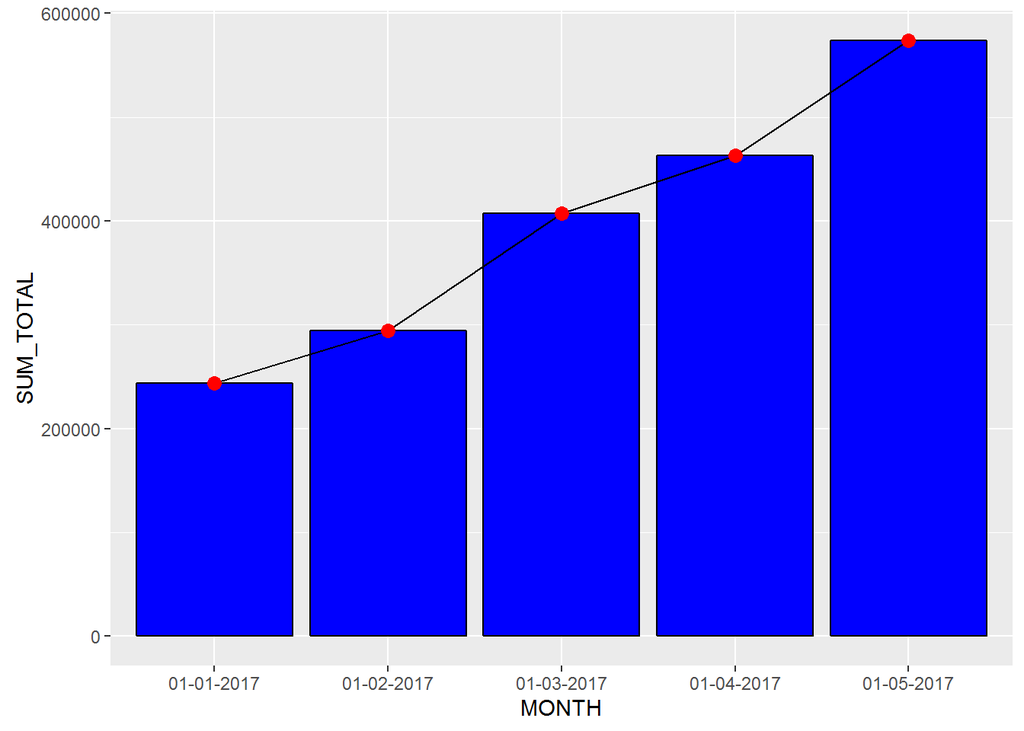

```r
a_sum = select(new_xyz, MONTH, WEIGHTED_TOTAL) %>%
  group_by(MONTH)%>%
  summarise(sum(WEIGHTED_TOTAL))

colnames(a_sum) = c('MONTH','SUM_TOTAL')

ggplot(a_sum,aes(MONTH,SUM_TOTAL,label=SUM_TOTAL)) +
  geom_bar(stat='identity',fill = 'blue', colour = "black") +
  geom_line(aes(group=1), colour="black") +
  geom_point(size=3, colour="red") +
  theme(legend.position = "none")
```

We can see overall trend is increasing from Jan to May. Now let’s look into data with COD_PREPAID wise.

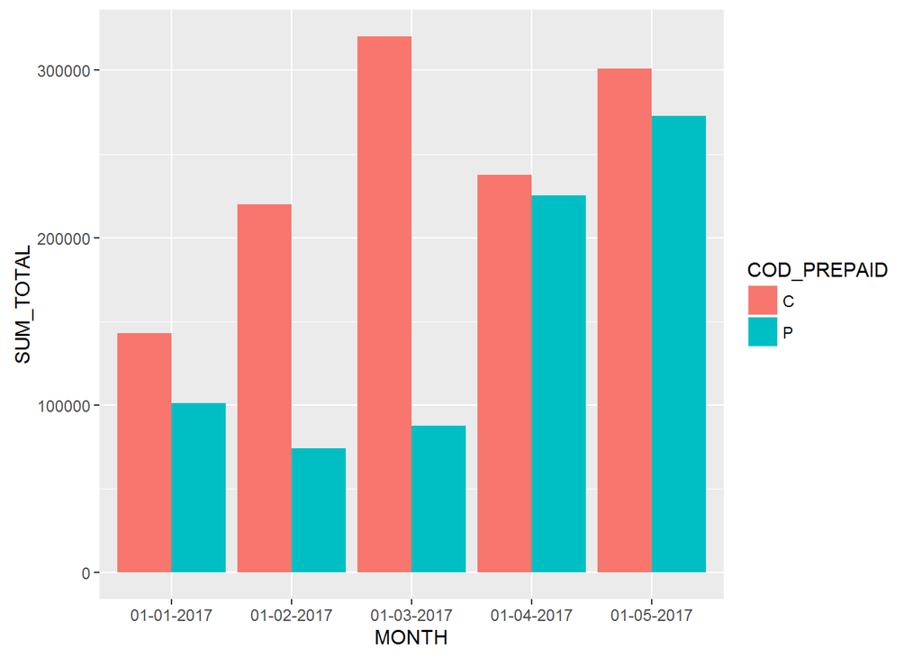

```r
b_sum = select(new_xyz, MONTH,COD_PREPAID, WEIGHTED_TOTAL) %>%
  group_by(MONTH,COD_PREPAID) %>%
  summarise(sum(WEIGHTED_TOTAL))

colnames(b_sum) = c('MONTH','COD_PREPAID','SUM_TOTAL')

ggplot(b_sum,aes(MONTH,SUM_TOTAL, fill=COD_PREPAID, label=SUM_TOTAL)) +
  geom_bar(stat='identity',position = 'dodge')
```

We can see prepaid customers 1st decreases from Jan to Feb, then increases from Feb to May.

Now let’s segregate the data month wise, which will help us on analyzing the performance of every destination area on monthly basis.

```r
#Monthwise data for all the DEST_AREA
jan_data =select(new_xyz, MONTH, DEST_AREA, COD_PREPAID, DEST_PIN, WEIGHTED_TOTAL) %>%
  filter(MONTH =='01-01-2017')
feb_data =select(new_xyz, MONTH, DEST_AREA, COD_PREPAID, DEST_PIN, WEIGHTED_TOTAL) %>%
  filter(MONTH =='01-02-2017')
mar_data =select(new_xyz, MONTH, DEST_AREA, COD_PREPAID, DEST_PIN, WEIGHTED_TOTAL) %>%
  filter(MONTH =='01-03-2017')
apr_data =select(new_xyz, MONTH, DEST_AREA, COD_PREPAID, DEST_PIN, WEIGHTED_TOTAL) %>%
  filter(MONTH =='01-04-2017')
may_data =select(new_xyz, MONTH, DEST_AREA, COD_PREPAID, DEST_PIN, WEIGHTED_TOTAL) %>%
  filter(MONTH =='01-05-2017')
```

Let’s group the data on destination areas, it will help us to figure out which are all the destinations showing reduction in volume in recent month.

```r
####Jan month analysis per dest_area w.r.t area####
sum_vol_jan = jan_data %>% group_by(DEST_AREA) %>% summarise(sum(WEIGHTED_TOTAL))
colnames(sum_vol_jan) = c('DEST_AREA','sum_jan')

####feb month analysis per dest_area w.r.t area####
sum_vol_feb = feb_data %>% group_by(DEST_AREA) %>% summarise(sum(WEIGHTED_TOTAL))
colnames(sum_vol_feb) = c('DEST_AREA','sum_feb')

####march month analysis per dest_area w.r.t area####
sum_vol_mar = mar_data %>% group_by(DEST_AREA) %>% summarise(sum(WEIGHTED_TOTAL))
colnames(sum_vol_mar) = c('DEST_AREA','sum_mar')

####april month analysis per dest_area w.r.t area####
sum_vol_apr = apr_data %>% group_by(DEST_AREA) %>% summarise(sum(WEIGHTED_TOTAL))
colnames(sum_vol_apr) = c('DEST_AREA','sum_apr')

####may month analysis per dest_area w.r.t area####
sum_vol_may = may_data %>% group_by(DEST_AREA) %>% summarise(sum(WEIGHTED_TOTAL))
colnames(sum_vol_may) = c('DEST_AREA','sum_may')

##Let's merge whole data into one data frame
sum_per_month = merge(x = sum_vol_jan, y = sum_vol_feb, by = "DEST_AREA", all = TRUE)
sum_per_month = merge(x = sum_per_month, y = sum_vol_mar, by = "DEST_AREA", all = TRUE)
sum_per_month = merge(x = sum_per_month, y = sum_vol_apr, by = "DEST_AREA", all = TRUE)
sum_per_month = merge(x = sum_per_month, y = sum_vol_may, by = "DEST_AREA", all = TRUE)
head(sum_per_month)
```

```
##   DEST_AREA sum_jan sum_feb sum_mar sum_apr sum_may
## 1     BDAAG   276.0   334.0   385.5    63.0    53.0
## 2     BDAAL     4.0      NA    18.0     7.0      NA
## 3     BDAAM      NA      NA    30.0      NA    27.0
## 4     BDABA   164.0   355.5   228.5   302.0   689.5
## 5     BDABD    27.5      NA   725.0   156.0    53.5
## 6     BDABG     1.0      NA    29.0   136.5   156.5
```

Here we can see missing values corresponding to few months for destinations. considering that if NA is present means no volume is delivered in those periods. Hence removing all NA’s with zero.

```r
sum_per_month[is.na(sum_per_month)] <- 0
head(sum_per_month)
```

```
##   DEST_AREA sum_jan sum_feb sum_mar sum_apr sum_may
## 1     BDAAG   276.0   334.0   385.5    63.0    53.0
## 2     BDAAL     4.0     0.0    18.0     7.0     0.0
## 3     BDAAM     0.0     0.0    30.0     0.0    27.0
## 4     BDABA   164.0   355.5   228.5   302.0   689.5
## 5     BDABD    27.5     0.0   725.0   156.0    53.5
## 6     BDABG     1.0     0.0    29.0   136.5   156.5
```

Let’s figure out the maximum value for each row out of 5 columns and then we will subtract our *May* data from it to find those areas where volume is reduced in *May*.

```r
sum_per_month[,'max_value'] = apply(sum_per_month[,2:6],1,max)
sum_per_month = sum_per_month %>% mutate(diff_max_may_sum = max_value - sum_may)
nrow(sum_per_month %>% filter(diff_max_may_sum > 0))
```

```
## [1] 512
```

We can see there are total 512 destination area which are showing reduction in volume, from it’s maximum volume delivered.  
Let’s look top 12 destination which are showing maximum reduction.

```r
xyz = t(select(sum_per_month,DEST_AREA,sum_jan, sum_feb,sum_mar,sum_apr,sum_may,diff_max_may_sum) %>%
  arrange(desc(diff_max_may_sum)) %>%
  head(12))

colnames(xyz) = xyz['DEST_AREA',]

xyz = cbind(rownames(xyz),xyz)
rownames(xyz) = NULL
colnames(xyz)[1] = c('SUM')
xyz = data.frame(xyz)

xyz[,2:13] <- lapply(xyz[,2:13], function(x) as.numeric(as.character(x)))
```

Let’s create a dashboard for these 12 destinations.

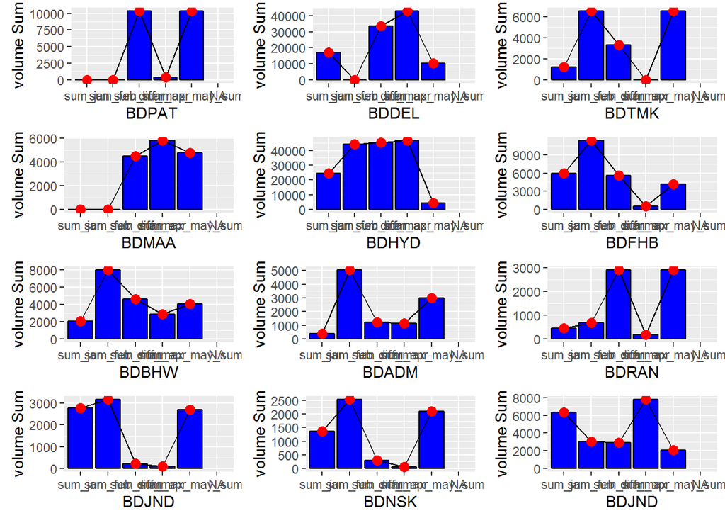

```r
xyz$SUM = factor(xyz$SUM, levels = c('sum_jan','sum_feb','sum_feb','sum_mar','sum_apr','sum_may','diff_max_may_sum'))
abc = xyz[-6,]
BDPAT = ggplot(abc,aes(abc$SUM,abc$BDPAT)) +
  geom_bar(stat='identity',fill = 'blue', colour = "black") +
  geom_line(aes(group=1), colour="black") +
  geom_point(size=3, colour="red") +
  theme(legend.position = "none") +
  labs(x = 'BDPAT', y = 'volume Sum')

BDDEL = ggplot(abc,aes(abc$SUM,abc$BDDEL)) +
  geom_bar(stat='identity',fill = 'blue', colour = "black") +
  geom_line(aes(group=1), colour="black") +
  geom_point(size=3, colour="red") +
  theme(legend.position = "none") +
  labs(x = 'BDDEL', y = 'volume Sum')

BDTMK = ggplot(abc,aes(abc$SUM,abc$BDTMK)) +
  geom_bar(stat='identity',fill = 'blue', colour = "black") +
  geom_line(aes(group=1), colour="black") +
  geom_point(size=3, colour="red") +
  theme(legend.position = "none") +
  labs(x = 'BDTMK', y = 'volume Sum')

BDMAA = ggplot(abc,aes(abc$SUM,abc$BDMAA)) +
  geom_bar(stat='identity',fill = 'blue', colour = "black") +
  geom_line(aes(group=1), colour="black") +
  geom_point(size=3, colour="red") +
  theme(legend.position = "none") +
  labs(x = 'BDMAA', y = 'volume Sum')

BDHYD = ggplot(abc,aes(abc$SUM,abc$BDHYD)) +
  geom_bar(stat='identity',fill = 'blue', colour = "black") +
  geom_line(aes(group=1), colour="black") +
  geom_point(size=3, colour="red") +
  theme(legend.position = "none") +
  labs(x = 'BDHYD', y = 'volume Sum')

BDFHB = ggplot(abc,aes(abc$SUM,abc$BDFHB)) +
  geom_bar(stat='identity',fill = 'blue', colour = "black") +
  geom_line(aes(group=1), colour="black") +
  geom_point(size=3, colour="red") +
  theme(legend.position = "none") +
  labs(x = 'BDFHB', y = 'volume Sum')

BDBHW = ggplot(abc,aes(abc$SUM,abc$BDBHW)) +
  geom_bar(stat='identity',fill = 'blue', colour = "black") +
  geom_line(aes(group=1), colour="black") +
  geom_point(size=3, colour="red") +
  theme(legend.position = "none") +
  labs(x = 'BDBHW', y = 'volume Sum')

BDADM = ggplot(abc,aes(abc$SUM,abc$BDADM)) +
  geom_bar(stat='identity',fill = 'blue', colour = "black") +
  geom_line(aes(group=1), colour="black") +
  geom_point(size=3, colour="red") +
  theme(legend.position = "none") +
  labs(x = 'BDADM', y = 'volume Sum')

BDRAN = ggplot(abc,aes(abc$SUM,abc$BDRAN)) +
  geom_bar(stat='identity',fill = 'blue', colour = "black") +
  geom_line(aes(group=1), colour="black") +
  geom_point(size=3, colour="red") +
  theme(legend.position = "none") +
  labs(x = 'BDRAN', y = 'volume Sum')

BDJND = ggplot(abc,aes(abc$SUM,abc$BDJND)) +
  geom_bar(stat='identity',fill = 'blue', colour = "black") +
  geom_line(aes(group=1), colour="black") +
  geom_point(size=3, colour="red") +
  theme(legend.position = "none") +
  labs(x = 'BDJND', y = 'volume Sum')

BDNSK = ggplot(abc,aes(abc$SUM,abc$BDNSK)) +
  geom_bar(stat='identity',fill = 'blue', colour = "black") +
  geom_line(aes(group=1), colour="black") +
  geom_point(size=3, colour="red") +
  theme(legend.position = "none") +
  labs(x = 'BDNSK', y = 'volume Sum')

BDGGN = ggplot(abc,aes(abc$SUM,abc$BDGGN)) +
  geom_bar(stat='identity',fill = 'blue', colour = "black") +
  geom_line(aes(group=1), colour="black") +
  geom_point(size=3, colour="red") +
  theme(legend.position = "none") +
  labs(x = 'BDJND', y = 'volume Sum')

layout = matrix(c(1,2,3,4,5,6,7,8,9,10,11,12),4,3,byrow=TRUE)

multiplot(BDPAT,BDDEL,BDTMK,BDMAA,BDHYD,BDFHB,BDBHW,BDADM,BDRAN,BDJND,BDNSK,BDGGN, layout=layout)
```

# 3 CONCLUSION